# ESM 204 HW 2

Sam Rozal, Virginia Pan, Kat Orellana

4/25/2022

```r
#read in data
water_districts <- read_csv(here("data", "Water_Districts.csv"))
```

# Number 1

For each irrigation district, plot the marginal abatement cost data (from the data provided) and estimate a linear regression model with zero intercept. These estimated linear regressions will be your estimates of the marginal abatement cost curve (one for each irrigation district), which you will use for the remainder of this analysis.

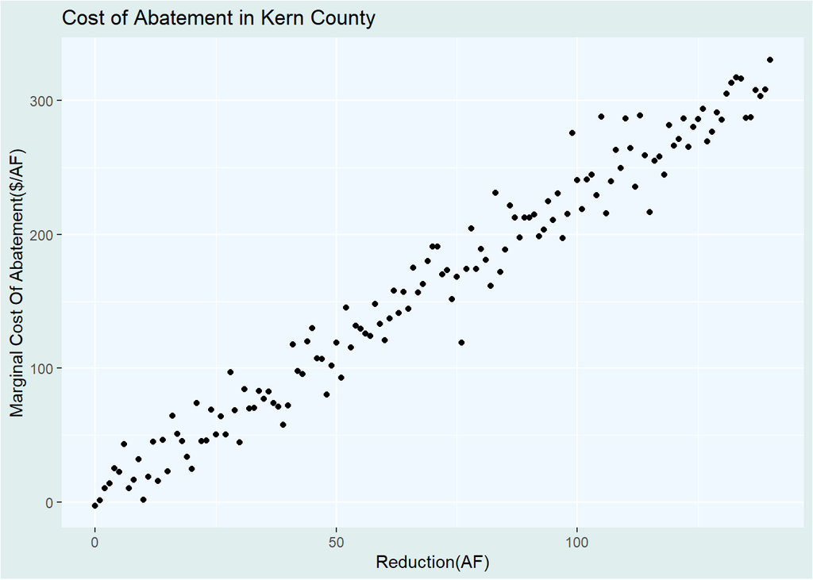

```r
#plot abatement for Kern county
ggplot(data=water_districts, aes(x=Reduction, y=MC_Kern))+
  geom_point()+
  labs(x="Reduction(AF)",
       y= "Marginal Cost Of Abatement($/AF)",
       title = "Cost of Abatement in Kern County")+
  theme(legend.background= element_rect(fill= "light blue"))+
  theme(plot.background = element_rect(fill="azure2")) +
  theme(panel.background = element_rect(fill="aliceblue"))
```

```r
#Find linear regression model for Kern county
kern_lm <- lm(MC_Kern ~ 0 + Reduction, data=water_districts)
```

Marginal Cost for Kern County = 2.286A

```r
#fitting line for kern
kern_baseline <- 150
kern_data <- tibble(Reduction = 0:150)
predicted_mc <- predict(kern_lm, newdata=kern_data)
kern_data <- kern_data %>% mutate(predicted_mc=predicted_mc)
```

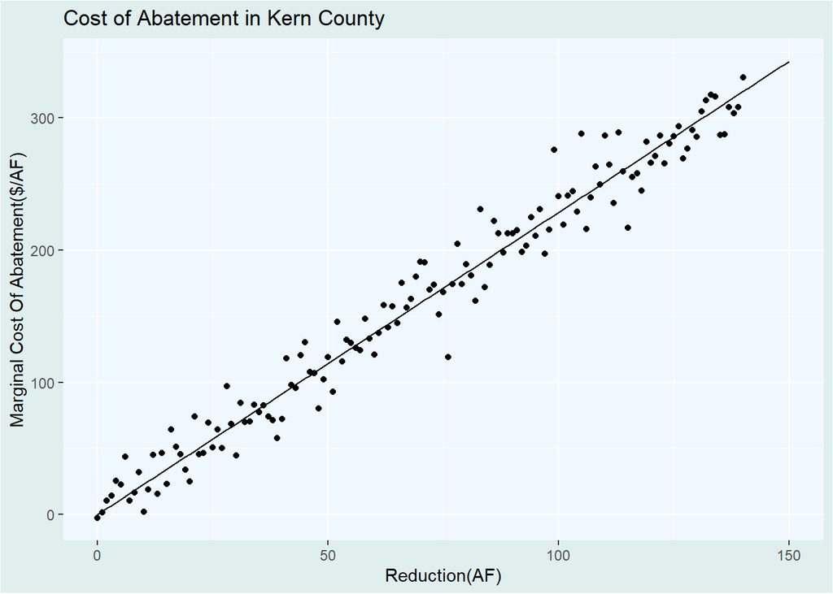

```r
#plotting with predicted line
ggplot(water_districts, aes(x=Reduction, y=MC_Kern))+
  geom_point()+
  geom_line(data=kern_data, aes(x=Reduction, y=predicted_mc))+
  labs(x="Reduction(AF)",
       y= "Marginal Cost Of Abatement($/AF)",
       title = "Cost of Abatement in Kern County")+
  theme(legend.background= element_rect(fill= "light blue"))+
  theme(plot.background = element_rect(fill="azure2")) +
  theme(panel.background = element_rect(fill="aliceblue"))
```

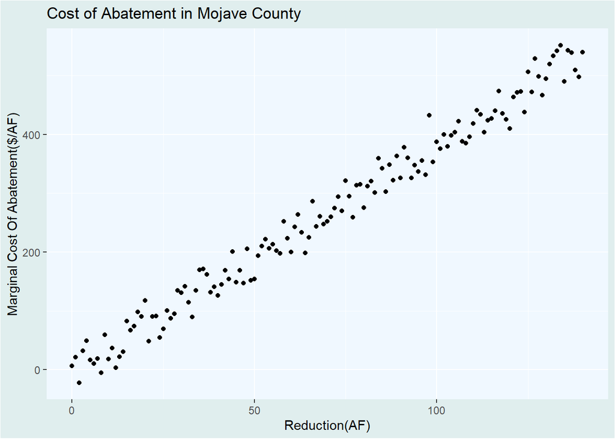

```r
#plot abatement for Mojave county
ggplot(data=water_districts, aes(x=Reduction, y=MC_Mojave))+
  geom_point()+
  labs(x="Reduction(AF)",
        y= "Marginal Cost Of Abatement($/AF)",
       title = "Cost of Abatement in Mojave County")+
  theme(legend.background= element_rect(fill= "light blue"))+
  theme(plot.background = element_rect(fill="azure2")) +
  theme(panel.background = element_rect(fill="aliceblue"))
```

```r
#Find linear regression model for Mojave county
mojave_lm <- lm(MC_Mojave ~ 0 + Reduction, data=water_districts)
mojave_lm_tidy <- broom::tidy(mojave_lm)
```

MC(A) for Mojave County = 3.804A

```r
#fitting line for Mojave
mojave_baseline <- 140
mojave_data <- tibble(Reduction = 0:140)
predicted_mc <- predict(mojave_lm, newdata=mojave_data)
mojave_data <- mojave_data %>% mutate(predicted_mc=predicted_mc)
```

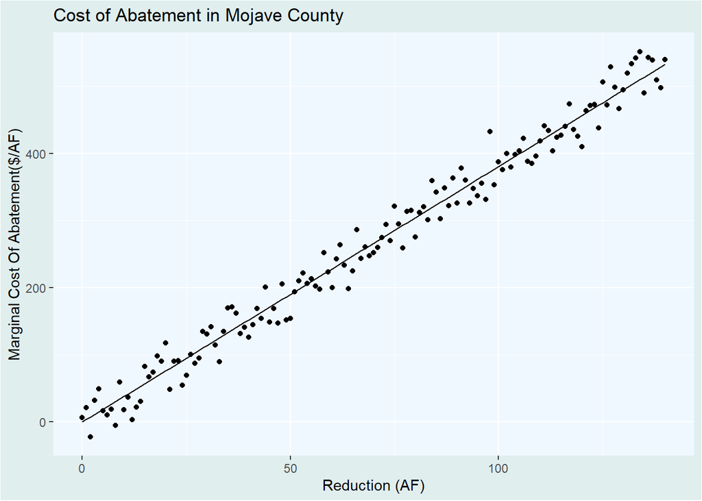

```r
#plotting with predicted line
ggplot(water_districts, aes(x=Reduction, y=MC_Mojave))+
  geom_point()+
  geom_line(data=mojave_data, aes(x=Reduction, y=predicted_mc))+
  labs(x="Reduction (AF)",
        y= "Marginal Cost Of Abatement($/AF)",
       title = "Cost of Abatement in Mojave County")+
  theme(legend.background= element_rect(fill= "light blue"))+
  theme(plot.background = element_rect(fill="azure2")) +
  theme(panel.background = element_rect(fill="aliceblue"))
```

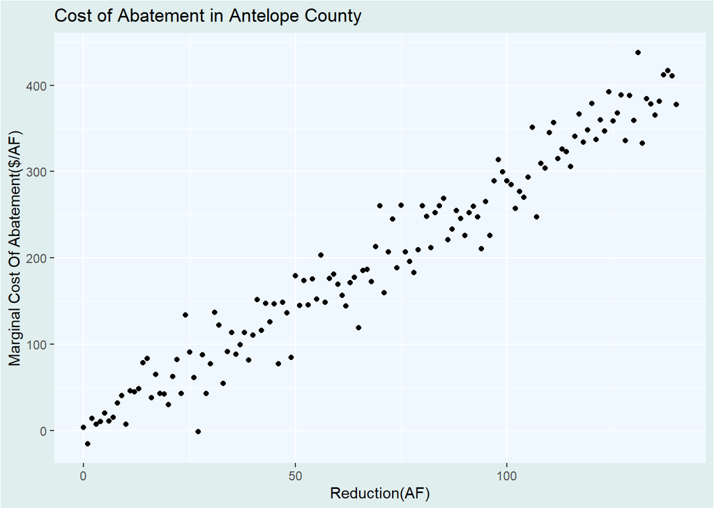

```r
#plot the abatement curve for antelope
ggplot(data=water_districts, aes(x=Reduction, y=MC_Antelope))+
  geom_point()+
  labs(x="Reduction(AF)",
        y= "Marginal Cost Of Abatement($/AF)",
       title = "Cost of Abatement in Antelope County")+
  theme(legend.background= element_rect(fill= "light blue"))+
  theme(plot.background = element_rect(fill="azure2")) +
  theme(panel.background = element_rect(fill="aliceblue"))
```

```r
antelope_lm <- lm(MC_Antelope ~ 0 + Reduction, data=water_districts)
antelope_lm_tidy <- broom::tidy(antelope_lm)
```

MC(A) for Antelope County = 2.858A

```r
#fitting line for antelope
antelope_baseline <- 220
antelope_data <- tibble(Reduction = 0:220)
predicted_mc <- predict(antelope_lm, newdata=antelope_data)
antelope_data <- antelope_data %>% mutate(predicted_mc=predicted_mc)
```

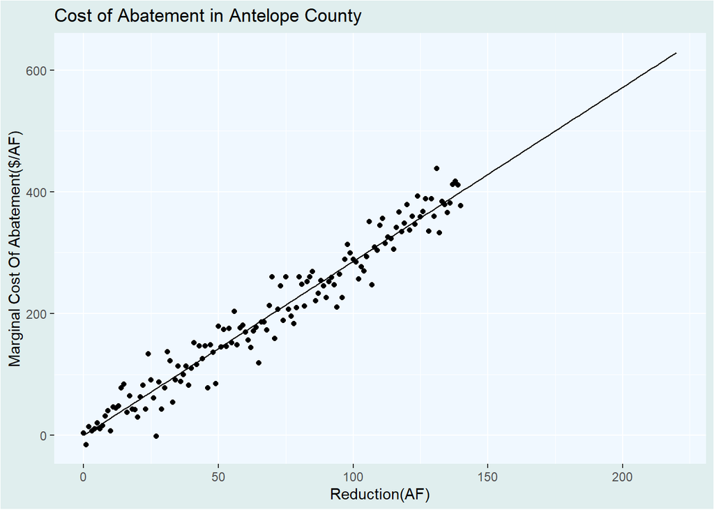

```r
#plotting with predicted line
ggplot(water_districts, aes(x=Reduction, y=MC_Antelope))+
  geom_point()+
  geom_line(data=antelope_data, aes(x=Reduction, y=predicted_mc))+
  labs(x="Reduction(AF)",
        y= "Marginal Cost Of Abatement($/AF)",
       title = "Cost of Abatement in Antelope County")+
  theme(legend.background= element_rect(fill= "light blue"))+
  theme(plot.background = element_rect(fill="azure2")) +
  theme(panel.background = element_rect(fill="aliceblue"))
```

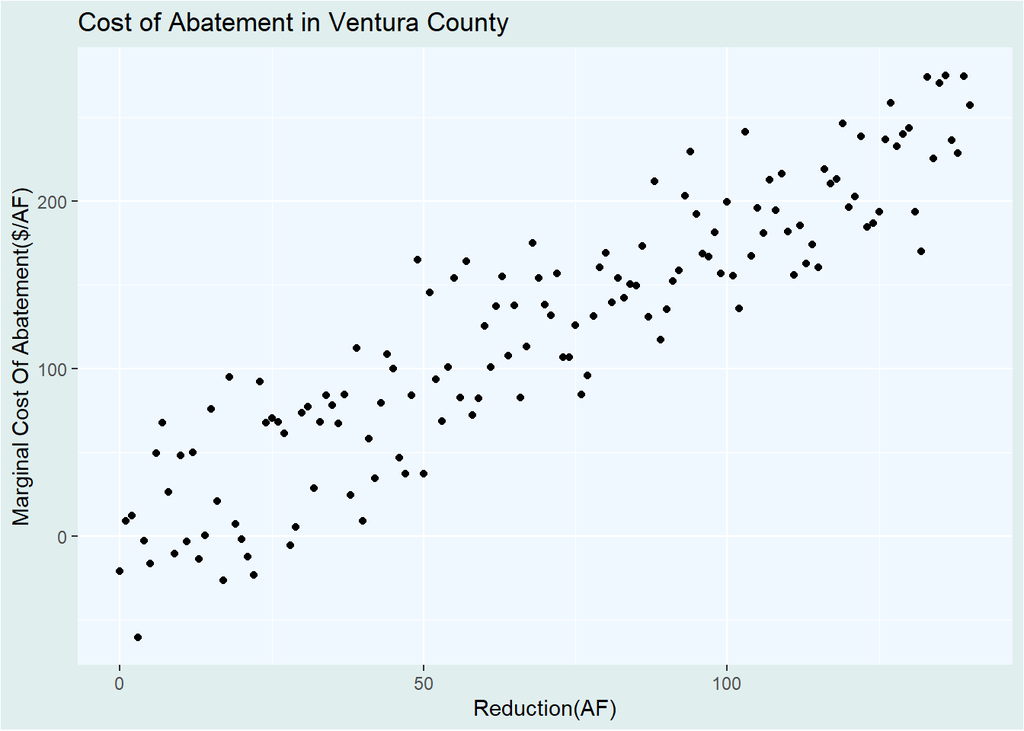

```r
ggplot(data=water_districts, aes(x=Reduction, y=MC_Ventura))+
  geom_point()+
  labs(x="Reduction(AF)",
        y= "Marginal Cost Of Abatement($/AF)",
       title = "Cost of Abatement in Ventura County")+
  theme(legend.background= element_rect(fill= "light blue"))+
  theme(plot.background = element_rect(fill="azure2")) +
  theme(panel.background = element_rect(fill="aliceblue"))
```

```r
ventura_lm <- lm(MC_Ventura ~ 0 + Reduction, data=water_districts)
ventura_lm_tidy <- broom::tidy(ventura_lm)
```

MC(A) for Ventura County = 1.776A

```r
#fitting line for Ventura
ventura_baseline <- 245
ventura_data <- tibble(Reduction = 0:245)
predicted_mc <- predict(ventura_lm, newdata=ventura_data)
ventura_data <- ventura_data %>% mutate(predicted_mc=predicted_mc)
```

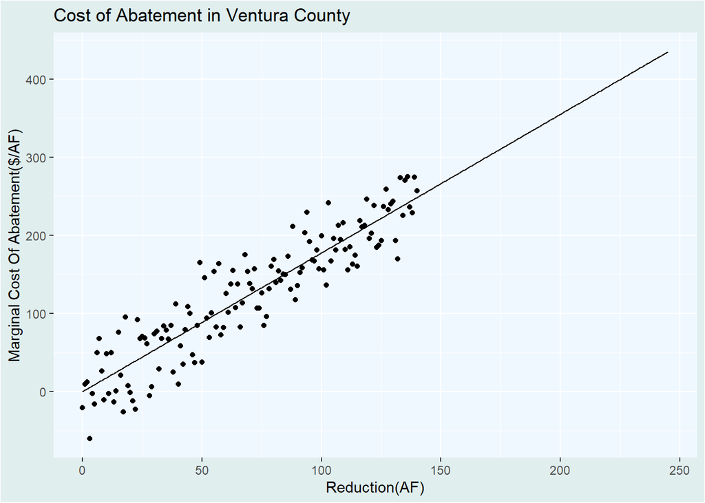

```r
#plotting with predicted line
ggplot(water_districts, aes(x=Reduction, y=MC_Ventura))+
  geom_point()+
  geom_line(data=ventura_data, aes(x=Reduction, y=predicted_mc))+
  labs(x="Reduction(AF)",
        y= "Marginal Cost Of Abatement($/AF)",
       title = "Cost of Abatement in Ventura County")+
  theme(legend.background= element_rect(fill= "light blue"))+
  theme(plot.background = element_rect(fill="azure2")) +
  theme(panel.background = element_rect(fill="aliceblue"))
```

### 2. Plot Demand Curves

Using your estimated marginal abatement cost curves, derive each district’s demand curve for water.In other words, how much would each district be willing to pay for the right to use the first AF of water,second AF, etc.? Plot each district’s demand curve on a single graph. Which sector is willing to pay the most for the first AF of water?

#### Kern County:

```r
#derive the demand curve for Kern County
#define demand or use as baseline (no policy) - Abatement
kern_data <- kern_data %>% mutate(water_demand=kern_baseline-Reduction)
```

To calculate demand for Kern County:

P= 2.286(A) and A= E0-E, where E0=150 AF

P= 2.286(E0-E)

P= 2.286(150-E)

P= 342.9 - 2.286E

Marginal Demand for Kern County = 342.9 - 2.286E

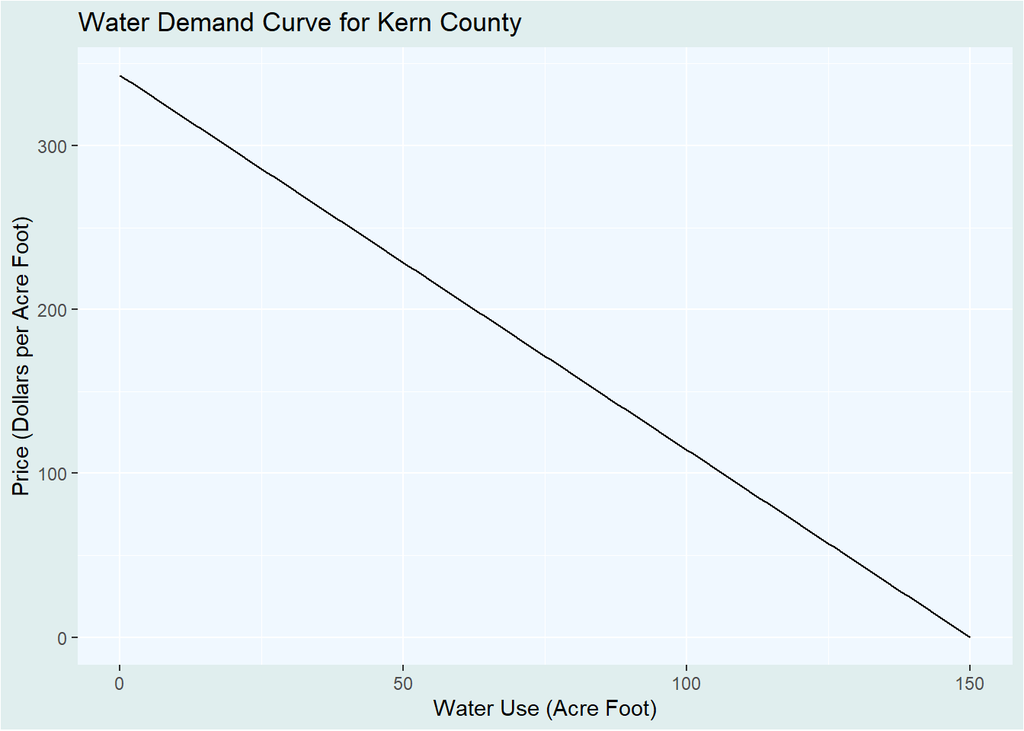

```r
#plot the demand for Kern County
ggplot(kern_data, aes(x=water_demand,y=predicted_mc))+
  geom_line() +
  labs(x="Water Use (Acre Foot)",
       y= "Price (Dollars per Acre Foot)",
       title = "Water Demand Curve for Kern County")+
  theme(legend.background= element_rect(fill= "light blue"))+
  theme(plot.background = element_rect(fill="azure2")) +
  theme(panel.background = element_rect(fill="aliceblue"))
```

#### Mojave County:

```r
#derive demand curve for Mojave county
#define demand or use as baseline (no policy) - Abatement
mojave_data <- mojave_data %>% mutate(water_demand=mojave_baseline-Reduction)
```

To calculate demand for Mojave County:

P= 3.804(A) and A= E0-E, where E0=140 AF

P= 3.804(E0-E)

P= 3.804(140-E)

P= 532.56 - 3.804E

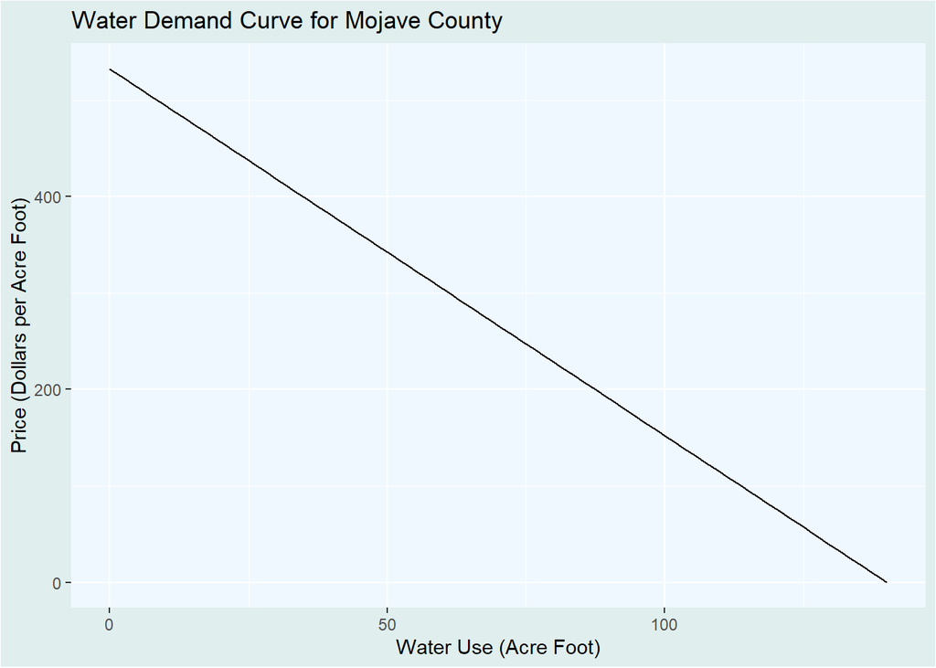

```r
#plot the demand for Mojave County
ggplot(mojave_data, aes(x=water_demand,y=predicted_mc))+
  geom_line() +
  labs(x="Water Use (Acre Foot)",
       y= "Price (Dollars per Acre Foot)",
       title = "Water Demand Curve for Mojave County")+
  theme(legend.background= element_rect(fill= "light blue"))+
  theme(plot.background = element_rect(fill="azure2")) +
  theme(panel.background = element_rect(fill="aliceblue"))
```

#### Antelope County:

```r
#derive demand curve for Antelope County
#define demand or use as baseline (no policy) - Abatement
antelope_data <- antelope_data %>% mutate(water_demand=antelope_baseline-Reduction)
```

To calculate demand for Antelope County:

P= 2.858(A) and A= E0-E, where E0=220 AF

P= 2.858(E0-E)

P= 2.858(220-E)

P= 628.76 - 2.858E

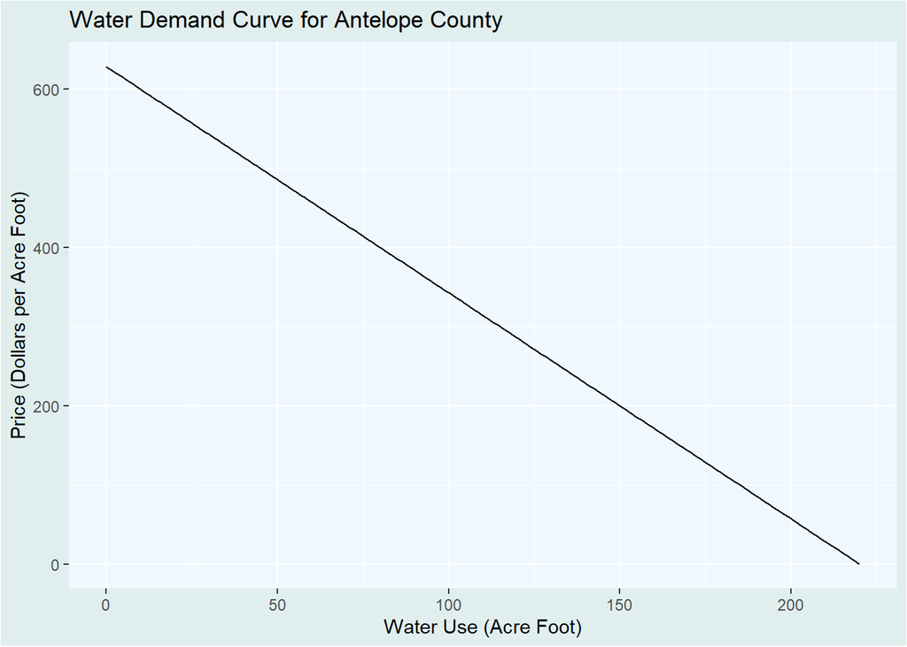

```r
#plot the demand curve for Antelope County
ggplot(antelope_data, aes(x=water_demand,y=predicted_mc))+
  geom_line() +
  labs(x="Water Use (Acre Foot)",
       y= "Price (Dollars per Acre Foot)",
       title = "Water Demand Curve for Antelope County")+
  theme(legend.background= element_rect(fill= "light blue"))+
  theme(plot.background = element_rect(fill="azure2")) +
  theme(panel.background = element_rect(fill="aliceblue"))
```

#### Ventura County:

```r
#derive demand curve for Ventura County
#define demand or use as baseline (no policy) - Abatement
ventura_data <- ventura_data %>% mutate(water_demand=ventura_baseline-Reduction)
```

To calculate demand for Ventura County:

P= 1.776(A) and A= E0-E, where E0=245 AF

P= 1.776(E0-E)

P= 1.776(245-E)

P= 435.12 - 1.776E

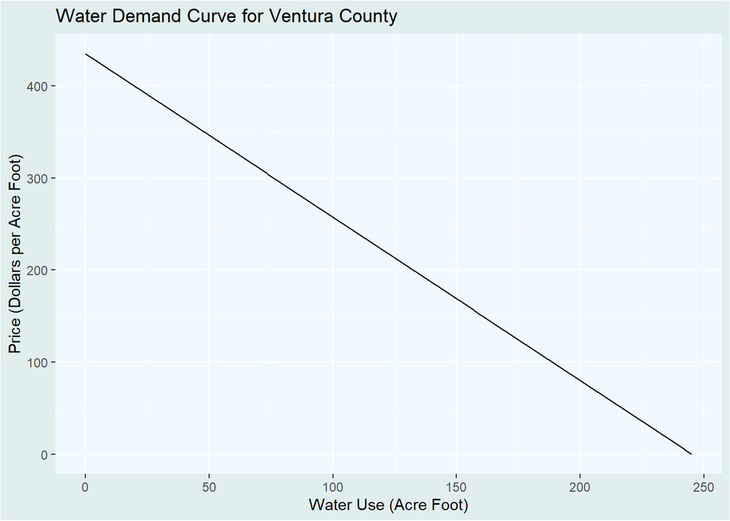

```r
#plot the demand for Ventura County
ggplot(ventura_data, aes(x=water_demand,y=predicted_mc))+
  geom_line() +
  labs(x="Water Use (Acre Foot)",
       y= "Price (Dollars per Acre Foot)",
       title = "Water Demand Curve for Ventura County")+
  theme(legend.background= element_rect(fill= "light blue"))+
  theme(plot.background = element_rect(fill="azure2")) +
  theme(panel.background = element_rect(fill="aliceblue"))
```

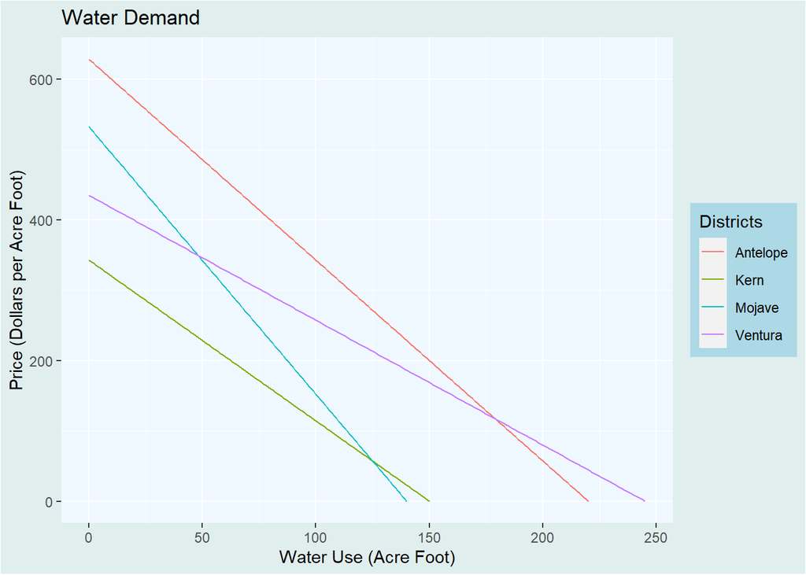

```r
#using demand data from Kern and Mojave, join into one data set for plotting
joined_demand <- bind_rows("Mojave" = mojave_data,
                           "Kern" = kern_data,
                           "Antelope" = antelope_data,
                           "Ventura" = ventura_data,
                           .id="Districts")


ggplot(data=joined_demand, aes(x=water_demand, y=predicted_mc))+
  geom_line(aes(color=Districts)) +
  labs(x="Water Use (Acre Foot)",
       y= "Price (Dollars per Acre Foot)",
       title = "Water Demand")+
  theme(legend.background= element_rect(fill= "light blue"))+
  theme(plot.background = element_rect(fill="azure2")) +
  theme(panel.background = element_rect(fill="aliceblue"))
```

Antelope irrigation district is willing to pay the most for the first acre-foot of water.

## Number 3

Here you will analyze three alternative policies for reducing water use among these irrigation districts.In total, these irrigation districts will need to reduce water consumption from the current 755 AF down to 500 AF. For each intervention listed below, perform the following calculations: (1) calculate the stringency of the policy (defined below for each intervention) required to achieve the 500 AF target, (2) calculate the total cost of meeting the target using that approach, (3) calculate the cost to each district, and (4) calculate the tax revenue generated.

a.Cap without trade. Reduce each district’s water use by the same fraction (e.g., 1/3 of current baseline use), so the 500 AF target is met. Trade is not allowed. Stringency is defined as the magnitude of the fraction.

Kern county:

- Abatement = baseline x 0.338
- Abatement = 150 X 0.338
- Abatement = 50.7

Mojave County:

- Abatement = baseline x 0.338
- Abatement = 140 X 0.338
- Abatement = 47.32

Antelope County:

- Abatement = baseline x 0.338
- Abatement = 220 X 0.338
- Abatement = 74.36

Ventura County:

- Abatement = baseline x 0.338
- Abatement = 245 X 0.338
- Abatement = 82.81

```r
#defining function
calc_cost <- function(lm_mod, quantity_abate){
  estimated_cost = lm_mod$coefficients[1]*quantity_abate
  total_cost = 0.5 * quantity_abate * estimated_cost
  return(total_cost[[1]])
}

#what is the total cost of kern were to abate 117 unit?
kern_cost <- calc_cost(kern_lm, quantity_abate = 50.7)

mojave_cost <- calc_cost(mojave_lm, quantity_abate = 47.32)

antelope_cost <- calc_cost(antelope_lm, quantity_abate = 74.36)

ventura_cost <- calc_cost(ventura_lm, quantity_abate = 82.81)

total_cost <- kern_cost + mojave_cost + antelope_cost + ventura_cost
```

Total cost is: 2.118765^{4}

Kern abatement cost is: 2938.5496288

Mojave abatement cost is: 4258.9592627

Antelope abatement cost is: 7900.5335673

Ventura abatement cost is: 6089.6075077

**b. Tax on water use. A single tax is implemented on all water use in each of the four districts, such that water use is reduced to the 500 AF target. Stringency is defined as the magnitude of the tax.**

To calculate the tax, I first need to find the Aggregated Marginal Cost equation. - This is done by first converting all of my marginal cost equations to solve for the Q variable because I will be horizontally summing and the Q value is the X value.

Kern County :

- P=2.286Q
- Q(kern) = (1/2.286)P

Mojave County:

- P=3.804Q
- Q(mojave) = (1/3.804)P

Antelope County:

- P=2.858Q
- Q(antelope) = (1/2.858)P

Ventura County:

- P=1.776Q
- Q(ventura) = (1/1.776)P

Now we add everything up to get the Q(agg)

- Q(agg) = Q(kern) + Q(mojave) + Q(antelope) + Q(ventura)
- Q(agg) = (1/2.286)P + (1/3.804)P + (1/2.858)P + (1/1.776)P
- Q(agg) = 1.613(P)

Now, to find P* at the Q* value, we plug in 255 as Qagg, because this is the amount of abatement that we want and then solve for P

- 255 = 1.613(P)
- P = 158.09
- P* = 158.09

Now, we need to calculate the Q value (quantity abated) associated with this P for each district/county’s marginal demand curve. To do this, we plug in P = 158.062 into each of the marginal cost curves.

Kern County :

- Q(kern) = (1/2.286)(158.09)
- Q(kern) = 69.14

Mojave County: P=3.804Q

- Q(mojave) = (1/3.804)(158.09)
- Q(mojave) = 41.56

Antelope County: P=2.858Q

- Q(antelope) = (1/2.858)(158.09)
- Q(antelope) = 55.31

Ventura County: P=1.776Q

- Q(ventura) = (1/1.776)(158.09)
- Q(ventura) = 89.01

```r
#caluclate the cost
kern_cost_b <- calc_cost(kern_lm, quantity_abate = 69.14)

mojave_cost_b <- calc_cost(mojave_lm, quantity_abate = 41.56)

antelope_cost_b <- calc_cost(antelope_lm, quantity_abate = 55.31)

ventura_cost_b <- calc_cost(ventura_lm, quantity_abate = 89.01)

total_cost_b <- kern_cost_b + mojave_cost_b + antelope_cost_b + ventura_cost_b
```

Cost of abatement with tax is: 2.015669^{4}

Kern cost of abatement cost with tax is: 5464.8199983

Mojave cost of abatement with tax is: 3285.2247943

Antelope cost of abatement with tax is: 4371.0419783

Ventura cost of abatement with tax is: 7035.6031524

However, in order to get the total cost incurred to each of the districts, we need to find how much they are paying the government for the water rights.

Stringency (magnitude of the tax) is: $158.09

```r
#calculate the revenue for tax 1
tax1 = 158.09

#write a function
calc_revenue <- function(tax_val, baseline,quantity_abate){
  revenue <- (tax_val * (baseline-quantity_abate))
  return(revenue)
}

revnue_kern <- calc_revenue(tax1, baseline=140,quantity_abate=69.14)
revnue_mojave <- calc_revenue(tax1, baseline=150,quantity_abate=41.56)
revnue_antelope <- calc_revenue(tax1, baseline=220,quantity_abate=55.31)
revnue_ventura <- calc_revenue(tax1, baseline=240,quantity_abate=89.01)


total_tax_revenue <- revnue_kern + revnue_antelope + revnue_ventura + revnue_mojave

#double check gov revenue calculations
#tax is on the amount of water used!
total_quantity_used = 500
total_tax_revenue2 = total_quantity_used*tax1
```

Total government revenue generated from tax: $7.8251388^{4}

Total cost under a tax:

To get this, we add cost of abatemnt under a tax and the amount they pay the government (revenue)

Cost of abatement with tax is: 9.8408078^{4}

Kern abatement cost with tax is: 1.6667077^{4}

Mojave abatement cost with tax is: 2.0428504^{4}

Antelope abatement cost with tax is: 3.0406884^{4}

Ventura abatement cost with tax is: 3.0905612^{4}

**c. Cap and trade. Cap water use as in part (a), but after those caps are set, allow trade across districts. How much water is used by each district after trade? Stringency is the same as in part (a).**

However there is the additional benefit that each district will get due to either revenue that they get from selling, or from getting to use more water than they would have under the original cap that needs to be accounted for to calculate total cost for each district. This is calculated below:

```r
#find the estimated p value both before and after trade
estimated_cost <- function(lm_mod, quantity_abate){
  (estimated_cost = lm_mod$coefficients[1]*quantity_abate)
  return(estimated_cost)
}

kern_before_trade <- estimated_cost(kern_lm,50.07)
kern_after_trade <- estimated_cost(kern_lm, 69.14)

mojave_before_trade <-estimated_cost(mojave_lm,47.32)
mojave_after_trade <-estimated_cost(mojave_lm,41.56)

antelope_before_trade <-estimated_cost(antelope_lm,74.36)
antelope_after_trade <-estimated_cost(antelope_lm,55.31)

ventura_before_trade <-estimated_cost(ventura_lm,82.81)
ventura_after_trade <-estimated_cost(ventura_lm,89.01)
```

```r
#function to get additional benefit(its essentially the area of a triangle)
additional_benefit <- function(p_before_trade,p_after_trade,q_before_trade,q_after_trade){
  (additional_benefit =(0.5)*(p_before_trade-p_after_trade)*(q_before_trade-q_after_trade))
  return(additional_benefit)
}

additional_benefit_kern <-additional_benefit(kern_before_trade, kern_after_trade, 50.07, 69.14)
additional_benefit_mojave <- additional_benefit(mojave_before_trade, mojave_after_trade,47.32,41.56)
additional_benefit_antelope <- additional_benefit(antelope_before_trade, antelope_after_trade,74.36,55.31)
additional_benefit_ventura <- additional_benefit(ventura_before_trade, ventura_after_trade,82.81,89.01)
```

Now we can get the total cost by subtracting the cost we got in a, minus the additional benefit.

```r
#kern county cost:
total_cost_kern <- kern_cost - additional_benefit_kern

total_cost_mojave <- mojave_cost - additional_benefit_mojave

total_cost_antelope <- antelope_cost - additional_benefit_antelope

total_cost_ventura <- ventura_cost - additional_benefit_ventura


total_cost_all <- total_cost_kern + total_cost_mojave + total_cost_antelope + total_cost_ventura
```

Stringency is the same as in part 1: 0.338

Total cost under cap and trade is: $ 2.0156151^{4}

Total cost under cap and trade for Kern is: $ 2522.8128017

Total cost under cap and trade for Mojave is: $ 4195.8549587

Total cost under cap and trade for Antelope is: $ 7382.0110503

Total cost under cap and trade for Ventura is: $ 6055.4719414

No Tax revenue is generated under cap and trade

# Number 4

A severe drought hits California, and it is necessary to reduce water use from 500 AF down to 300 AF. Your job is to estimate the cost of the drought (i.e., the cost of reducing water use from 500 AF to 300 AF) to each irrigation district under each policy. Considering the entire jump from status quo (755 AF) to the drought (300 AF), which policy is preferred by each irrigation district? How does your answer depend on how rights are allocated to each district (in policies (a) and (c))2?

**a. Cap without trade. Reduce each district’s water use by the same fraction (e.g., 1/3 of current baseline use), so the 300 AF target is met. Trade is not allowed. Stringency is defined as the magnitude of the fraction.**

Kern county:

- Abatement = baseline x 0.599
- Abatement = 150 X 0.599
- Abatement = 89.85

Mojave County:

- Abatement = baseline x 0.599
- Abatement = 140 X 0.599
- Abatement = 83.86

Antelope County:

- Abatement = baseline x 0.599
- Abatement = 220 X 0.599
- Abatement = 131.78

Ventura County:

```r
#defining function for cost
calc_cost <- function(lm_mod, quantity_abate){
  estimated_cost = lm_mod$coefficients[1]*quantity_abate
  total_cost = 0.5 * quantity_abate * estimated_cost
  return(total_cost[[1]])
}

#calculate cost based on abatement
kern_cost_4 <- calc_cost(kern_lm, quantity_abate = 89.85)

mojave_cost_4<- calc_cost(mojave_lm, quantity_abate = 83.86)

antelope_cost_4 <- calc_cost(antelope_lm, quantity_abate = 131.78)

ventura_cost_4 <- calc_cost(ventura_lm, quantity_abate = 146.76)

#calculate
total_cost_4 <- kern_cost_4 + mojave_cost_4 + antelope_cost_4 + ventura_cost_4
```

Total cost is: 6.6544404^{4}

Kern abatement cost is: 9228.9708464

Mojave abatement cost is: 1.3375922^{4}

Antelope abatement cost is: 2.4812851^{4}

Ventura abatement cost is: 1.912666^{4}

**b. Tax on water use. A single tax is implemented on all water use in each of the four districts, such that water use is reduced to the 300 AF target. Stringency is defined as the magnitude of the tax.**

To calculate the tax, we first need to find the Aggregated Marginal Cost equation.

- This is done by first converting all of my marginal cost equations to solve for the Q variable because I will be horizontally summing and the Q value is the X value.

Kern County :

- P=2.286Q
- Q(kern) = (1/2.286)P

Mojave County: - P=3.804Q

- Q(mojave) = (1/3.804)P

Antelope County:

- P=2.858Q
- Q(antelope) = (1/2.858)P

Ventura County:

- P=1.776Q
- Q(ventura) = (1/1.776)P

Now we add this all up to get the Q(agg)

-Q(agg) = Q(kern) + Q(mojave) + Q(antelope) + Q(ventura)

- Q(agg) = (1/2.286)P + (1/3.804)P + (1/2.858)P + (1/1.776)P
- Q(agg) = 1.613(P)

Now, to find P* at the Q* value, we plug in 455 as Qagg, because this is the amount of abatement that we want and then solve for P

- 455 = 1.613(P)
- P = 282.08
- P* = 282.08

Kern County :

- P=2.286Q
- Q(kern) = (1/2.286)(282.08)
- Q(kern) = 123.39

Mojave County:

- P=3.804Q
- Q(mojave) = (1/3.804)(282.08)
- Q(mojave) = 74.15

Antelope County:

- P=2.858Q
- Q(antelope) = (1/2.858)(282.08)
- Q(antelope) = 98.70

Ventura County:

- P=1.776Q
- Q(ventura) = (1/1.776)(282.08)
- Q(ventura) = 158.83

```r
kern_cost_b_4 <- calc_cost(kern_lm, quantity_abate = 123.39)

mojave_cost_b_4 <- calc_cost(mojave_lm, quantity_abate = 74.15)

antelope_cost_b_4 <- calc_cost(antelope_lm, quantity_abate = 98.70)

ventura_cost_b_4 <- calc_cost(ventura_lm, quantity_abate = 158.83)

total_cost_b_4 <- kern_cost_b_4 + mojave_cost_b_4 + antelope_cost_b_4 + ventura_cost_b_4
```

Total cost of abatement with tax is: 6.4184054^{4}

Kern cost of abatement with tax is: 1.7405121^{4}

Mojave cost of abatement with tax is: 1.0457704^{4}

Antelope cost of abatement with tax is: 1.3919126^{4}

Ventura cost of abatement with tax is: 2.2402104^{4}

However, in order to get the total cost incurred to each of the districts, we need to find how much they are paying the government for the water rights.

So, Next we calculue the government revenue

```r
#calculate the revenue for tax 2
tax2 = 282.08

#write a function
calc_revenue <- function(tax_val, baseline,quantity_abate){
  revenue <- (tax_val * (baseline-quantity_abate))
  return(revenue)
}

revnue_kern_4 <- calc_revenue(tax2,baseline=140,quantity_abate=123.39)
revnue_mojave_4 <- calc_revenue(tax2,baseline=150,quantity_abate=74.15)
revnue_antelope_4 <- calc_revenue(tax2,baseline=220,quantity_abate=98.70)
revnue_ventura_4 <- calc_revenue(tax2,baseline=245,quantity_abate=158.83)


total_tax_revenue_4 <- revnue_kern_4 + revnue_antelope_4 + revnue_ventura_4 + revnue_mojave_4

#double check gov revenue calculations
#tax is on the amount of water used!
total_quantity_used_4 = 300
total_tax_revenue2_4 = total_quantity_used_4*tax2
```

Total cost under a tax:

To get this, we add cost of abatemnt under a tax and the amount they pay the government (revenue)

Cost of abatement with tax is: 1.4878831^{5}

Kern abatement cost with tax is: 2.209047^{4}

Mojave abatement cost with tax is: 3.1853472^{4}

Antelope abatement cost with tax is: 4.813543^{4}

Ventura abatement cost with tax is: 4.6708937^{4}

**c. Cap and trade. Cap water use as in part (a), but after those caps are set, allow trade across districts. How much water is used by each district after trade? Stringency is the same as in part (a).**

For Cap and Trade, we set the initial Q values for each of the four districts so that it is the same as in part (a) so Kern abates 89.85 AF, Mojave abates 83.86 AF, Antelope abates 131.78 AF, and Ventura abates 146.76 AF. However because trading is allowed, the districts will buy and sell their water rights, to reach the socially optimal point which is what we found under part b. Therefore in the end, Kern abates 123.39 AF, Mojave abates 74.15 AF, Antelope abates 98.70 AF, and Ventura abates 158.83 AF.

However there is the additional benefit that each district will get due to either revenue that they get from selling, or from getting to use more water than they would have under the original cap. This is calculated below:

```r
#find the estimated p value both before and after trade
estimated_cost <- function(lm_mod, quantity_abate){
  (estimated_cost = lm_mod$coefficients[1]*quantity_abate)
  return(estimated_cost)
}

kern_before_trade_4 <- estimated_cost(kern_lm,89.85)
kern_after_trade_4<- estimated_cost(kern_lm, 123.39)

mojave_before_trade_4 <-estimated_cost(mojave_lm,83.86)
mojave_after_trade_4 <-estimated_cost(mojave_lm,74.15)

antelope_before_trade_4 <-estimated_cost(antelope_lm,131.78)
antelope_after_trade_4 <-estimated_cost(antelope_lm,98.70)

ventura_before_trade_4 <-estimated_cost(ventura_lm,146.76)
ventura_after_trade_4 <-estimated_cost(ventura_lm,158.83)
```

```r
additional_benefit <- function(p_before_trade,p_after_trade,q_before_trade,q_after_trade){
  (additional_benefit =(0.5)*(p_before_trade-p_after_trade)*(q_before_trade-q_after_trade))
  return(additional_benefit)
}

additional_benefit_kern_4 <-additional_benefit(kern_before_trade_4, kern_after_trade_4, 89.85, 123.39)
additional_benefit_mojave_4<- additional_benefit(mojave_before_trade_4, mojave_after_trade_4,83.86,74.15)
additional_benefit_antelope_4<- additional_benefit(antelope_before_trade_4, antelope_after_trade_4, 131.78,98.70)
additional_benefit_ventura_4 <- additional_benefit(ventura_before_trade_4, ventura_after_trade_4,146.76,158.83)
```

Now we can get the total cost by subtracting the cost we got in a, minus the additional benefit.

```r
#kern county cost:
total_cost_kern_4 <- kern_cost_4 - additional_benefit_kern_4

total_cost_mojave_4 <- mojave_cost_4 - additional_benefit_mojave_4

total_cost_antelope_4 <- antelope_cost_4 - additional_benefit_antelope_4

total_cost_ventura_4 <- ventura_cost_4 - additional_benefit_ventura_4


total_cost_all_4 <- total_cost_kern_4 + total_cost_mojave_4 + total_cost_antelope_4 + total_cost_ventura_4
```

Total cost under cap and trade is: $ 6.3386157^{4}

Total cost under cap and trade for Kern is: $ 7942.9641568

Total cost under cap and trade for Mojave is: $ 1.3196592^{4}

Total cost under cap and trade for Antelope is: $ 2.3249312^{4}

Total cost under cap and trade for Ventura is: $ 1.8997289^{4}

Overall,

Kern

- Cap without trade: $9228
- Tax: $22090.47
- Cap and Trade: $7942

Mojave

- Cap without trade: $13375
- Tax: $31853.47
- Cap and Trade: $13196.59

Antelope:

- Cap without trade: $24812
- Tax: $48135.43
- Cap and Trade: $23249.31

Ventura:

- Cap without trade: $19126
- Tax: $46708.93
- Cap and Trade: $18997.29

Therefore, Kern would prefer Cap and Trade, Mojave would prefer Cap and Trade, Antelope would prefer Cap and Trade, and Ventura would prefer Cap and Trade because these are the scenarios/policies that have the lowest cost to each district.

Our answer depends on how rights are allocated to each district in policies a and c because in a cap without trade scenario a district only has the rights they are allocated, whereas in a cap and trade scenario they can trade rights to reach maximum benefit for all parties involved. Depending on the rights allocated in the cap without trade scenario , some districts would loose out on a significant benefit that may be aqqured from either selling or buying additional water rights.